# DE: Common EW vs LGEP

Adam Festa

4/16/2018

## Script summary and setup

There are a few common families which were grown in both the EW and LGEP batches. Given that principal component plots of the whole data set indicate a large batch effect, there is interest in seeing how different the transcripts expressed in the common families across batches is. The goal of this script is to test for DE between families which are present in both batches and have at least 3 biological replicates.

To accomplish this we will use bioloigcal replicates which were previously processed with Salmon and the 86k transcriptome The R packages tximport + DESeq2 can be used to test for differential expression and evalute if any transcripts are consistantly variable across batches.

- Load the tximport object which contains biological replciates

  ```r
    # bio counts
    load("/media/disk6/ARF/RNASEQ/counts/86kSalmon/bio_rep_txi_count_data_object.RData")
    names(txi)
  ```

  ```
  ## [1] "abundance"           "counts"              "variance"
  ## [4] "length"              "countsFromAbundance"
  ```

  - The txi object is a list of 5 elements containing the counts, bootstrap variance estimates, and effect txpt lengths for each respective sample.
- Load complete experimental meta data

  ```r
    # expt data
    load("/media/disk6/ARF/RNASEQ/Breeding-Value-Prediction/disk6directory/resources/expt.dat.720.RData")
    dim(expt.dat.720)
  ```

  ```
  ## [1] 720  36
  ```

  - The experimental data set contain 720 rows and 36 columns. Each row correspond to a technical replicate and each column corresponds to a piece of meta-deta describing the techincal replicate.
  - Note that the experimental data needs to be consolidated to bioloigcal replicates in order to match the txi object. This will be done next by identifying the column names and removing certain ones which uniquely describe the techincal replicates.
- Print the column names of the experimental data frame.

  ```r
  colnames(expt.dat.720)
  ```

  ```
  ##  [1] "animal_id"          "fam_id"             "p1"
  ##  [4] "p2"                 "batch"              "lane"
  ##  [7] "index_seq"          "fl_mean"            "index_let"
  ## [10] "sample_id"          "salmon_input_path"  "p_info"
  ## [13] "Height"             "Height Accuracy"    "Height LB"
  ## [16] "Height UB"          "Volume"             "Volume Accuracy"
  ## [19] "Volume LB"          "Volume UB"          "Rust"
  ## [22] "Rust Accuracy"      "Rust LB"            "Rust UB"
  ## [25] "Rust Grade"         "Strt"               "Strt Accuracy"
  ## [28] "Strt LB"            "Strt UB"            "Strt Grade"
  ## [31] "Fork"               "Fork Accuracy"      "Fork LB"
  ## [34] "Fork UB"            "Fork Grade"         "salmon_output_path"
  ```

  - Lot’s of info in here. The ones which are unique to technical replicates within a given biological replicate are:
    - lane (col 6)
    - fl_mean (col 8)
    - salmple_id (col 10)
    - salmon_input_path (col 11)
    - salmon_output_path (col 36)
- Remove the above columns and create bioloigcal replicate experimental data set

  ```r
  rm.cols <- c(6,8,10,11,36)

  expt.dat.240 <- droplevels.data.frame(unique(expt.dat.720[,-c(rm.cols)]))
  dim(expt.dat.240)
  ```

  ```
  ## [1] 240  31
  ```

- Now that we have both the count data and experimental meta data consolidated to bioloigcal replicates, let’s check that they are in same order.

  ```r
  # print the column names of the counts (biological replicate names)
  head(colnames(txi$counts))
  ```

  ```
  ## [1] "1030." "1028." "1075." "1087." "1013." "1079."
  ```

  ```r
  #look at name of animal.id (bioloigcal replicate) in experimental info
  head(expt.dat.240$animal_id)
  ```

  ```
  ## [1] 1030 1028 1075 1087 1013 1079
  ## 240 Levels: 1 10 100 1001 1002 1003 1004 1005 1006 1007 1008 1009 ... 99
  ```

  - Note that column names in the counts are characters while the experimental data animal id is a numeric factor.
  - Also, note that each biological sample name in the counts has a “.” at the end which will force R to never specify this as anything but a character variable.
- Add period to end of animal id, check order, and assign as row names of expt data frame

  ```r
  tmp.names <- paste0(as.character(expt.dat.240$animal_id),".")
  identical(tmp.names,colnames(txi$counts))
  ```

  ```
  ## [1] TRUE
  ```

  ```r
  rownames(expt.dat.240) <- tmp.names
  ```

## Subset comparisons to be made

Since this script will only utilize families which show up in the EW and LGEP,as well as have at least 3 bioloigcal replicates, let’s identify those families and subset them from the data frames

- Identify families which are in EW && LGEP

  ```r
  lgep.fams <- unique(as.character(expt.dat.240$fam_id)[which(expt.dat.240$batch == "LGEP")])
  ew.fams <- unique(as.character(expt.dat.240$fam_id)[which(expt.dat.240$batch == "EW")])
  both.batch.fams <- ew.fams[which(ew.fams %in% lgep.fams)]
  print(both.batch.fams)
  ```

  ```
  ## [1] "N111095" "N08103"  "N101027" "N08001"  "N07056"
  ```

- Subset these families from the phenotype matrix

  ```r
  ew.lgep.fams <- which(as.character(expt.dat.240$fam_id) %in% both.batch.fams)
  ew.lgep.phenos <- droplevels.data.frame(expt.dat.240[ew.lgep.fams,])
  ```

- Subset these families from txi object

  ```r
  # Subset ew families from counts
  txi$counts <- txi$counts[,ew.lgep.fams]

  # Filter out which transcripts have less than 10 total counts
  rm.zero <- which(apply(txi$counts,1,sum) < 10)
  txi$counts <- txi$counts[-c(rm.zero),]

  # Remove low counts and subset ew/lgep fams from txi object
  txi$abundance <- txi$abundance[-c(rm.zero),ew.lgep.fams]
  txi$length <- txi$length[-c(rm.zero),ew.lgep.fams]
  txi$variance <- txi$variance[-c(rm.zero),ew.lgep.fams]
  ```

- Generate pc plot and check outliers

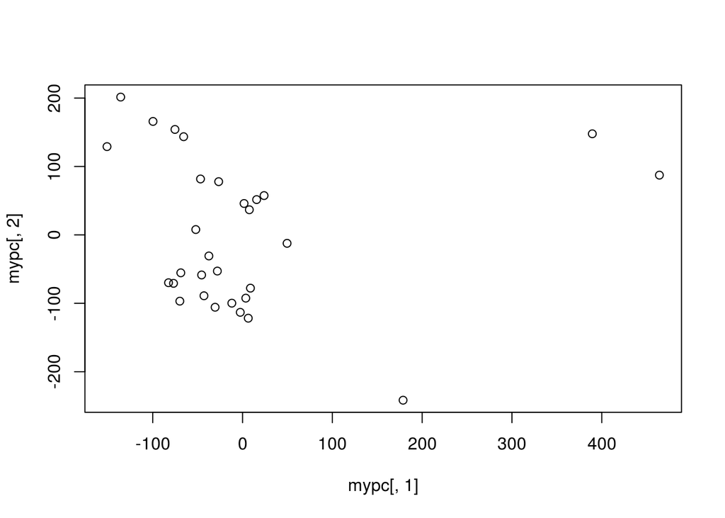

  ```r
  # Use the counts to create a pc plot and plot the first two
  mypc <- prcomp(t(txi$counts),center = T,scale. = T)
  mypc <- mypc$x[,1:2]

  plot(mypc[,1],mypc[,2])
  ```

  ```r
  # Which reps are to the right of the plot?
  which(mypc[,1] > 150)
  ```

  ```
  ## 1084. 1083.   67.
  ##     9    14    25
  ```

- Remove outlier biological replicates

  ```r
  # Identify the rows which correspond to the outliers
  rm.bio.reps <- (which(mypc[,1] > 150))

  # Table the family ID with the outliers excluded (we want 3 bio reps per batch (6 total))
  table(as.character(ew.lgep.phenos$fam_id[-c(rm.bio.reps)]))
  ```

  ```
  ##
  ##  N07056  N08001  N08103 N101027 N111095
  ##       5       8       2       6       6
  ```

  ```r
  # Remove the two families which do not have at least 3 biological reps per batch
  rm.fams <- which(as.character(ew.lgep.phenos$fam_id) %in% c("N07056","N08103"))

  # Subset the txi and pheno objects to remove families with less than 3 bio reps per batch
  txi$counts <- txi$counts[,-c(rm.fams)]
  txi$abundance <- txi$abundance[,-c(rm.fams)]
  txi$variance <- txi$variance[,-c(rm.fams)]
  txi$length <- txi$length[,-c(rm.fams)]

  ew.lgep.phenos <- droplevels.data.frame(ew.lgep.phenos[-c(rm.fams),])

  ew.lgep.phenos[1:5,1:5]
  ```

  ```
  ##       animal_id  fam_id      p1 p2 batch
  ## 1030.      1030 N111095 N111095 NA    EW
  ## 1008.      1008 N101027 N101027 NA    EW
  ## 1093.      1093  N08001  N08001 NA    EW
  ## 1029.      1029 N111095 N111095 NA    EW
  ## 1031.      1031 N111095 N111095 NA    EW
  ```

  ```r
  unique(ew.lgep.phenos$fam_id)
  ```

  ```
  ## [1] N111095 N101027 N08001
  ## Levels: N08001 N101027 N111095
  ```

The txi object and ew.lgep.phenos can now be used in DESeq2

## Run DESeq2

- Load DESeq2 library, create new variable that pastes together batch+fam, and create DESeq object

  ```r
  suppressPackageStartupMessages(library(DESeq2))
  ew.lgep.phenos$batch.fam <- as.factor(paste0(ew.lgep.phenos$fam_id,ew.lgep.phenos$batch))

  ddsTXI <- DESeqDataSetFromTximport(txi = txi,colData = ew.lgep.phenos,design = ~ 0 + index_seq + batch.fam)
  ```

  ```
  ## using counts and average transcript lengths from tximport
  ```

  ```r
  ddsTXI <- DESeq(ddsTXI,parallel = T,minReplicatesForReplace = Inf)
  ```

  ```
  ## using 'avgTxLength' from assays(dds), correcting for library size
  ```

- Run the first 3 direct comparisons of famX_EW vs. famX_LGEP

  ```r
  resultsNames(ddsTXI)
  ```

  ```
  ##  [1] "index_seqATCACG"      "index_seqATGTCA"      "index_seqATTCCT"
  ##  [4] "index_seqCGATGT"      "index_seqCGTACG"      "index_seqCTTGTA"
  ##  [7] "index_seqGAGTGG"      "index_seqGCCAAT"      "index_seqGGCTAC"
  ## [10] "index_seqGTCCGC"      "index_seqGTGGCC"      "index_seqTAGCTT"
  ## [13] "index_seqTGACCA"      "index_seqTTAGGC"      "batch.famN08001LGEP"
  ## [16] "batch.famN101027EW"   "batch.famN101027LGEP" "batch.famN111095EW"
  ## [19] "batch.famN111095LGEP"
  ```

  ```r
  res.1 <- results(object = ddsTXI,contrast = c("batch.fam", "N101027LGEP","N101027EW"),parallel = T,pAdjustMethod = "bonferroni",lfcThreshold = 1.2,alpha = .05)

  res.2 <- results(object = ddsTXI,contrast = c("batch.fam", "N111095LGEP","N111095EW"),parallel = T,pAdjustMethod = "bonferroni",lfcThreshold = 1.2,alpha = .05)

  res.3 <- results(object = ddsTXI,contrast = c("batch.fam", "N08001LGEP","N08001EW"),parallel = T,pAdjustMethod = "bonferroni",lfcThreshold = 1.2,alpha = .05)
  ```

- Run comparisons within EW

  ```r
  ew.1 <- results(object = ddsTXI,contrast = c("batch.fam", "N111095EW","N101027EW"),parallel = T,pAdjustMethod = "bonferroni",lfcThreshold = 1.2,alpha = .05)
  ew.2 <- results(object = ddsTXI,contrast = c("batch.fam", "N111095EW","N08001EW"),parallel = T,pAdjustMethod = "bonferroni",lfcThreshold = 1.2,alpha = .05)
  ew.3 <- results(object = ddsTXI,contrast = c("batch.fam", "N101027EW","N08001EW"),parallel = T,pAdjustMethod = "bonferroni",lfcThreshold = 1.2,alpha = .05)
  ```

- Run comparisons within LGEP

  ```r
  lgep.1 <- results(object = ddsTXI,contrast = c("batch.fam", "N111095LGEP","N101027LGEP"),parallel = T,pAdjustMethod = "bonferroni",lfcThreshold = 1.2,alpha = .05)
  lgep.2 <- results(object = ddsTXI,contrast = c("batch.fam", "N111095LGEP","N08001LGEP"),parallel = T,pAdjustMethod = "bonferroni",lfcThreshold = 1.2,alpha = .05)
  lgep.3 <- results(object = ddsTXI,contrast = c("batch.fam", "N101027LGEP","N08001LGEP"),parallel = T,pAdjustMethod = "bonferroni",lfcThreshold = 1.2,alpha = .05)
  ```

- Run comparisons EW vs. LGEP

  ```r
  l.e.1 <- results(object = ddsTXI,contrast = c("batch.fam", "N111095LGEP","N101027EW"),parallel = T,pAdjustMethod = "bonferroni",lfcThreshold = 1.2,alpha = .05)
  l.e.2 <- results(object = ddsTXI,contrast = c("batch.fam", "N111095LGEP","N08001EW"),parallel = T,pAdjustMethod = "bonferroni",lfcThreshold = 1.2,alpha = .05)
  l.e.3 <- results(object = ddsTXI,contrast = c("batch.fam", "N101027LGEP","N08001EW"),parallel = T,pAdjustMethod = "bonferroni",lfcThreshold = 1.2,alpha = .05)

  e.l.1 <- results(object = ddsTXI,contrast = c("batch.fam", "N111095EW","N101027LGEP"),parallel = T,pAdjustMethod = "bonferroni",lfcThreshold = 1.2,alpha = .05)
  e.l.2 <- results(object = ddsTXI,contrast = c("batch.fam", "N111095EW","N08001LGEP"),parallel = T,pAdjustMethod = "bonferroni",lfcThreshold = 1.2,alpha = .05)
  e.l.3 <- results(object = ddsTXI,contrast = c("batch.fam", "N101027EW","N08001LGEP"),parallel = T,pAdjustMethod = "bonferroni",lfcThreshold = 1.2,alpha = .05)
  ```

All comparisons are done, now we can evaluate the total number of DE transcripts.

## Results

- Create empty list to store output:

  ```r
  all.results <- vector("list")
  ```

- Direct comparison:

  ```r
  # N101027 LGEP vs. EW
  summary(res.1)
  ```

  ```
  ##
  ## out of 77538 with nonzero total read count
  ## adjusted p-value < 0.05
  ## LFC > 1.20 (up)    : 23, 0.03%
  ## LFC < -1.20 (down) : 10, 0.013%
  ## outliers [1]       : 0, 0%
  ## low counts [2]     : 49600, 64%
  ## (mean count < 127)
  ## [1] see 'cooksCutoff' argument of ?results
  ## [2] see 'independentFiltering' argument of ?results
  ```

  ```r
  all.results[[1]] <- rownames(subset(res.1,padj < .05))
  # N111095 LGEP vs. EW
  summary(res.2)
  ```

  ```
  ##
  ## out of 77538 with nonzero total read count
  ## adjusted p-value < 0.05
  ## LFC > 1.20 (up)    : 27, 0.035%
  ## LFC < -1.20 (down) : 16, 0.021%
  ## outliers [1]       : 0, 0%
  ## low counts [2]     : 42085, 54%
  ## (mean count < 76)
  ## [1] see 'cooksCutoff' argument of ?results
  ## [2] see 'independentFiltering' argument of ?results
  ```

  ```r
  all.results[[2]] <- rownames(subset(res.2,padj < .05))
  # N08001 LGEP vs. EW
  summary(res.3)
  ```

  ```
  ##
  ## out of 77538 with nonzero total read count
  ## adjusted p-value < 0.05
  ## LFC > 1.20 (up)    : 137, 0.18%
  ## LFC < -1.20 (down) : 17, 0.022%
  ## outliers [1]       : 0, 0%
  ## low counts [2]     : 33067, 43%
  ## (mean count < 40)
  ## [1] see 'cooksCutoff' argument of ?results
  ## [2] see 'independentFiltering' argument of ?results
  ```

  ```r
  all.results[[3]] <- rownames(subset(res.3,padj < .05))

  # These txpts show up in all 3 comparisons
  which(table(unlist(all.results)) == 3)
  ```

  ```
  ## 0_3699_Contig3_817_2373       est_Pita_49627472       est_Pita_51899958
  ##                       1                      50                      56
  ##       est_pita_61670525       est_Pita_61773836       est_Pita_61776063
  ##                      75                      82                      85
  ##       est_pita_66976169       est_Pita_74155894       est_Pita_74160484
  ##                      98                     154                     158
  ##             isotig47155
  ##                     187
  ```